# Optimal Treatment Analysis

## Outcome Variable

**Outcome Variable:** haz

## Predictor Variables

**Intervention Variable:** hfoodsec

**Adjustment Set:**

- arm
- sex
- W_mage
- meducyrs
- feducyrs
- hhwealth_quart
- vagbrth
- W_nrooms
- W_nchldlt5
- brthmon
- W_parity
- impfloor
- impsan
- safeh20
- delta_W_mage
- delta_meducyrs
- delta_feducyrs
- delta_hhwealth_quart
- delta_vagbrth
- delta_W_nrooms
- delta_W_nchldlt5
- delta_brthmon
- delta_W_parity
- delta_impfloor
- delta_impsan
- delta_safeh20

## Stratifying Variables

The analysis was stratified on these variable(s):

- agecat
- studyid
- country

## Data Summary

| agecat | studyid | country | hfoodsec | n_cell | n |
| --- | --- | --- | --- | --- | --- |
| Birth | ki0047075b-MAL-ED | BANGLADESH | Food Secure | 144 | 172 |
| Birth | ki0047075b-MAL-ED | BANGLADESH | Mildly Food Insecure | 4 | 172 |
| Birth | ki0047075b-MAL-ED | BANGLADESH | Food Insecure | 24 | 172 |
| Birth | ki0047075b-MAL-ED | BRAZIL | Food Secure | 0 | 28 |
| Birth | ki0047075b-MAL-ED | BRAZIL | Mildly Food Insecure | 4 | 28 |
| Birth | ki0047075b-MAL-ED | BRAZIL | Food Insecure | 24 | 28 |
| Birth | ki0047075b-MAL-ED | INDIA | Food Secure | 34 | 37 |
| Birth | ki0047075b-MAL-ED | INDIA | Mildly Food Insecure | 1 | 37 |
| Birth | ki0047075b-MAL-ED | INDIA | Food Insecure | 2 | 37 |
| Birth | ki0047075b-MAL-ED | NEPAL | Food Secure | 10 | 14 |
| Birth | ki0047075b-MAL-ED | NEPAL | Mildly Food Insecure | 1 | 14 |
| Birth | ki0047075b-MAL-ED | NEPAL | Food Insecure | 3 | 14 |
| Birth | ki0047075b-MAL-ED | PERU | Food Secure | 24 | 91 |
| Birth | ki0047075b-MAL-ED | PERU | Mildly Food Insecure | 23 | 91 |
| Birth | ki0047075b-MAL-ED | PERU | Food Insecure | 44 | 91 |
| Birth | ki0047075b-MAL-ED | SOUTH AFRICA | Food Secure | 45 | 88 |
| Birth | ki0047075b-MAL-ED | SOUTH AFRICA | Mildly Food Insecure | 9 | 88 |
| Birth | ki0047075b-MAL-ED | SOUTH AFRICA | Food Insecure | 34 | 88 |
| Birth | ki1017093-NIH-Birth | BANGLADESH | Food Secure | 90 | 608 |
| Birth | ki1017093-NIH-Birth | BANGLADESH | Mildly Food Insecure | 478 | 608 |
| Birth | ki1017093-NIH-Birth | BANGLADESH | Food Insecure | 40 | 608 |
| Birth | ki1017093c-NIH-Crypto | BANGLADESH | Food Secure | 439 | 732 |
| Birth | ki1017093c-NIH-Crypto | BANGLADESH | Mildly Food Insecure | 209 | 732 |
| Birth | ki1017093c-NIH-Crypto | BANGLADESH | Food Insecure | 84 | 732 |
| Birth | ki1113344-GMS-Nepal | NEPAL | Food Secure | 477 | 672 |
| Birth | ki1113344-GMS-Nepal | NEPAL | Mildly Food Insecure | 106 | 672 |
| Birth | ki1113344-GMS-Nepal | NEPAL | Food Insecure | 89 | 672 |
| Birth | kiGH5241-JiVitA-3 | BANGLADESH | Food Secure | 6951 | 14364 |
| Birth | kiGH5241-JiVitA-3 | BANGLADESH | Mildly Food Insecure | 4877 | 14364 |
| Birth | kiGH5241-JiVitA-3 | BANGLADESH | Food Insecure | 2536 | 14364 |

[output cut: 69 more lines]

The following strata were considered:

- agecat: 24 months, studyid: ki0047075b-MAL-ED, country: BANGLADESH
- agecat: 24 months, studyid: ki0047075b-MAL-ED, country: BRAZIL
- agecat: 24 months, studyid: ki0047075b-MAL-ED, country: INDIA
- agecat: 24 months, studyid: ki0047075b-MAL-ED, country: NEPAL
- agecat: 24 months, studyid: ki0047075b-MAL-ED, country: PERU
- agecat: 24 months, studyid: ki0047075b-MAL-ED, country: SOUTH AFRICA
- agecat: 24 months, studyid: ki1017093-NIH-Birth, country: BANGLADESH
- agecat: 24 months, studyid: ki1017093c-NIH-Crypto, country: BANGLADESH
- agecat: 24 months, studyid: ki1113344-GMS-Nepal, country: NEPAL
- agecat: 24 months, studyid: kiGH5241-JiVitA-3, country: BANGLADESH
- agecat: 24 months, studyid: kiGH5241-JiVitA-4, country: BANGLADESH
- agecat: 6 months, studyid: ki0047075b-MAL-ED, country: BANGLADESH
- agecat: 6 months, studyid: ki0047075b-MAL-ED, country: BRAZIL
- agecat: 6 months, studyid: ki0047075b-MAL-ED, country: INDIA
- agecat: 6 months, studyid: ki0047075b-MAL-ED, country: NEPAL
- agecat: 6 months, studyid: ki0047075b-MAL-ED, country: PERU
- agecat: 6 months, studyid: ki0047075b-MAL-ED, country: SOUTH AFRICA
- agecat: 6 months, studyid: ki1017093-NIH-Birth, country: BANGLADESH
- agecat: 6 months, studyid: ki1017093c-NIH-Crypto, country: BANGLADESH
- agecat: 6 months, studyid: ki1113344-GMS-Nepal, country: NEPAL
- agecat: 6 months, studyid: kiGH5241-JiVitA-3, country: BANGLADESH
- agecat: 6 months, studyid: kiGH5241-JiVitA-4, country: BANGLADESH
- agecat: Birth, studyid: ki0047075b-MAL-ED, country: BANGLADESH
- agecat: Birth, studyid: ki0047075b-MAL-ED, country: BRAZIL
- agecat: Birth, studyid: ki0047075b-MAL-ED, country: INDIA
- agecat: Birth, studyid: ki0047075b-MAL-ED, country: NEPAL
- agecat: Birth, studyid: ki0047075b-MAL-ED, country: PERU
- agecat: Birth, studyid: ki0047075b-MAL-ED, country: SOUTH AFRICA
- agecat: Birth, studyid: ki1017093-NIH-Birth, country: BANGLADESH
- agecat: Birth, studyid: ki1017093c-NIH-Crypto, country: BANGLADESH
- agecat: Birth, studyid: ki1113344-GMS-Nepal, country: NEPAL
- agecat: Birth, studyid: kiGH5241-JiVitA-3, country: BANGLADESH
- agecat: Birth, studyid: kiGH5241-JiVitA-4, country: BANGLADESH

### Dropped Strata

Some strata were dropped due to rare outcomes:

- agecat: Birth, studyid: ki0047075b-MAL-ED, country: BANGLADESH
- agecat: Birth, studyid: ki0047075b-MAL-ED, country: BRAZIL
- agecat: Birth, studyid: ki0047075b-MAL-ED, country: INDIA
- agecat: Birth, studyid: ki0047075b-MAL-ED, country: NEPAL
- agecat: 6 months, studyid: ki0047075b-MAL-ED, country: BANGLADESH
- agecat: 6 months, studyid: ki0047075b-MAL-ED, country: BRAZIL
- agecat: 24 months, studyid: ki0047075b-MAL-ED, country: BANGLADESH
- agecat: 24 months, studyid: ki0047075b-MAL-ED, country: BRAZIL

## Methods Detail

We’re interested in the causal parameters $E[Y_a]$ for all values of $a \in \mathcal{A}$. These parameters represent the mean outcome if, possibly contrary to fact, we intervened to set all units to have $A=a$. Under the randomization and positivity assumptions, these are identified by the statistical parameters $\psi_a=E_W[E_{Y|A,W}(Y|A=a,W)]$. In addition, we’re interested in the mean of $Y$, $E[Y]$ under no intervention (the observed mean). We will estimate these parameters by using SuperLearner to fit the relevant likelihood factors – $E_{Y|A,W}(Y|A=a,W)$ and $p(A=a|W)$, and then updating our likelihood fit using a joint TMLE.

For unadjusted analyses ($W=\{\}$), initial likelihoods were estimated using Lrnr_glm to estimate the simple $E(Y|A)$ and Lrnr_mean to estimate $p(A)$. For adjusted analyses, a small library containing Lrnr_glmnet, Lrnr_xgboost, and Lrnr_mean was used.

Having estimated these parameters, we will then use the delta method to estimate relative risks and attributable risks relative to a prespecified baseline level of $A$.

# Results Detail

## Results Plots

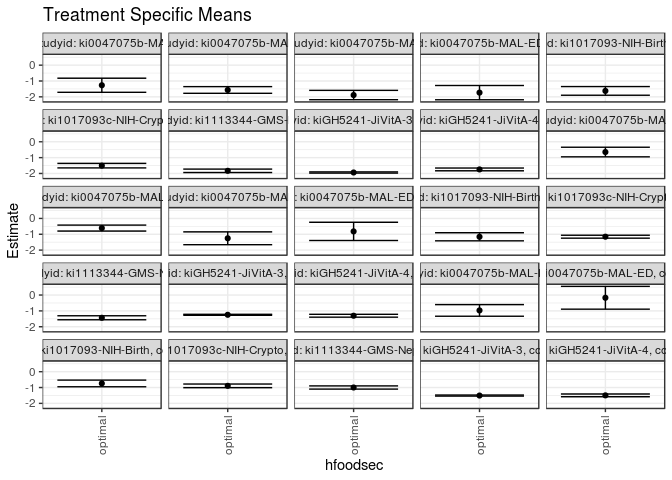

## Results Table

### Parameter: TSM

| agecat | studyid | country | intervention_level | baseline_level | estimate | ci_lower | ci_upper |
| --- | --- | --- | --- | --- | --- | --- | --- |
| Birth | ki0047075b-MAL-ED | PERU | optimal | observed | -0.9696081 | -1.3360509 | -0.6031653 |
| Birth | ki0047075b-MAL-ED | SOUTH AFRICA | optimal | observed | -0.1711804 | -0.8906064 | 0.5482455 |
| Birth | ki1017093-NIH-Birth | BANGLADESH | optimal | observed | -0.7414717 | -0.9509443 | -0.5319990 |
| Birth | ki1017093c-NIH-Crypto | BANGLADESH | optimal | observed | -0.8933691 | -1.0084310 | -0.7783071 |
| Birth | ki1113344-GMS-Nepal | NEPAL | optimal | observed | -0.9986113 | -1.1005409 | -0.8966818 |
| Birth | kiGH5241-JiVitA-3 | BANGLADESH | optimal | observed | -1.5066321 | -1.5401184 | -1.4731459 |
| Birth | kiGH5241-JiVitA-4 | BANGLADESH | optimal | observed | -1.4947721 | -1.5811769 | -1.4083674 |
| 6 months | ki0047075b-MAL-ED | INDIA | optimal | observed | -0.6467388 | -0.9495926 | -0.3438851 |
| 6 months | ki0047075b-MAL-ED | NEPAL | optimal | observed | -0.6097540 | -0.7977605 | -0.4217476 |
| 6 months | ki0047075b-MAL-ED | PERU | optimal | observed | -1.2537350 | -1.6583912 | -0.8490788 |
| 6 months | ki0047075b-MAL-ED | SOUTH AFRICA | optimal | observed | -0.8189788 | -1.3951162 | -0.2428414 |
| 6 months | ki1017093-NIH-Birth | BANGLADESH | optimal | observed | -1.1590353 | -1.4151466 | -0.9029240 |
| 6 months | ki1017093c-NIH-Crypto | BANGLADESH | optimal | observed | -1.1537950 | -1.2458781 | -1.0617119 |
| 6 months | ki1113344-GMS-Nepal | NEPAL | optimal | observed | -1.4344811 | -1.5612280 | -1.3077342 |
| 6 months | kiGH5241-JiVitA-3 | BANGLADESH | optimal | observed | -1.2452898 | -1.2754886 | -1.2150911 |
| 6 months | kiGH5241-JiVitA-4 | BANGLADESH | optimal | observed | -1.3064281 | -1.3966543 | -1.2162019 |
| 24 months | ki0047075b-MAL-ED | INDIA | optimal | observed | -1.2685219 | -1.7132861 | -0.8237576 |
| 24 months | ki0047075b-MAL-ED | NEPAL | optimal | observed | -1.5661339 | -1.7765647 | -1.3557030 |
| 24 months | ki0047075b-MAL-ED | PERU | optimal | observed | -1.8868168 | -2.1809634 | -1.5926701 |
| 24 months | ki0047075b-MAL-ED | SOUTH AFRICA | optimal | observed | -1.7340527 | -2.1850285 | -1.2830768 |
| 24 months | ki1017093-NIH-Birth | BANGLADESH | optimal | observed | -1.6259012 | -1.8995456 | -1.3522568 |
| 24 months | ki1017093c-NIH-Crypto | BANGLADESH | optimal | observed | -1.5065296 | -1.6491360 | -1.3639232 |
| 24 months | ki1113344-GMS-Nepal | NEPAL | optimal | observed | -1.8328475 | -1.9410977 | -1.7245973 |
| 24 months | kiGH5241-JiVitA-3 | BANGLADESH | optimal | observed | -1.9384731 | -1.9776256 | -1.8993206 |
| 24 months | kiGH5241-JiVitA-4 | BANGLADESH | optimal | observed | -1.7442164 | -1.8319345 | -1.6564983 |

### Parameter: E(Y)

| agecat | studyid | country | intervention_level | baseline_level | estimate | ci_lower | ci_upper |
| --- | --- | --- | --- | --- | --- | --- | --- |
| Birth | ki0047075b-MAL-ED | PERU | observed | observed | -0.9490110 | -1.1400314 | -0.7579906 |
| Birth | ki0047075b-MAL-ED | SOUTH AFRICA | observed | observed | -0.5503409 | -0.7616444 | -0.3390374 |
| Birth | ki1017093-NIH-Birth | BANGLADESH | observed | observed | -0.9310197 | -1.0197391 | -0.8423003 |
| Birth | ki1017093c-NIH-Crypto | BANGLADESH | observed | observed | -0.9094945 | -0.9809370 | -0.8380521 |
| Birth | ki1113344-GMS-Nepal | NEPAL | observed | observed | -1.0791964 | -1.1604792 | -0.9979137 |
| Birth | kiGH5241-JiVitA-3 | BANGLADESH | observed | observed | -1.5375132 | -1.5596692 | -1.5153573 |
| Birth | kiGH5241-JiVitA-4 | BANGLADESH | observed | observed | -1.5248719 | -1.5743851 | -1.4753587 |
| 6 months | ki0047075b-MAL-ED | INDIA | observed | observed | -1.2019969 | -1.3256948 | -1.0782989 |
| 6 months | ki0047075b-MAL-ED | NEPAL | observed | observed | -0.6262760 | -0.7758267 | -0.4767254 |
| 6 months | ki0047075b-MAL-ED | PERU | observed | observed | -1.3783784 | -1.5611768 | -1.1955799 |
| 6 months | ki0047075b-MAL-ED | SOUTH AFRICA | observed | observed | -1.0539254 | -1.1902766 | -0.9175743 |
| 6 months | ki1017093-NIH-Birth | BANGLADESH | observed | observed | -1.4073821 | -1.4960598 | -1.3187043 |
| 6 months | ki1017093c-NIH-Crypto | BANGLADESH | observed | observed | -1.1986783 | -1.2700937 | -1.1272630 |
| 6 months | ki1113344-GMS-Nepal | NEPAL | observed | observed | -1.3421764 | -1.4201083 | -1.2642445 |
| 6 months | kiGH5241-JiVitA-3 | BANGLADESH | observed | observed | -1.3131326 | -1.3362851 | -1.2899801 |
| 6 months | kiGH5241-JiVitA-4 | BANGLADESH | observed | observed | -1.3446891 | -1.3822219 | -1.3071564 |
| 24 months | ki0047075b-MAL-ED | INDIA | observed | observed | -1.8868396 | -2.0164954 | -1.7571839 |
| 24 months | ki0047075b-MAL-ED | NEPAL | observed | observed | -1.4092187 | -1.5701249 | -1.2483126 |
| 24 months | ki0047075b-MAL-ED | PERU | observed | observed | -1.7783956 | -1.9536701 | -1.6031212 |
| 24 months | ki0047075b-MAL-ED | SOUTH AFRICA | observed | observed | -1.6331323 | -1.7704624 | -1.4958022 |
| 24 months | ki1017093-NIH-Birth | BANGLADESH | observed | observed | -2.2190579 | -2.3217459 | -2.1163699 |
| 24 months | ki1017093c-NIH-Crypto | BANGLADESH | observed | observed | -1.4412646 | -1.5249156 | -1.3576135 |
| 24 months | ki1113344-GMS-Nepal | NEPAL | observed | observed | -1.8758368 | -1.9623349 | -1.7893388 |
| 24 months | kiGH5241-JiVitA-3 | BANGLADESH | observed | observed | -2.0099416 | -2.0377955 | -1.9820876 |
| 24 months | kiGH5241-JiVitA-4 | BANGLADESH | observed | observed | -1.7801485 | -1.8158427 | -1.7444543 |

### Parameter: PAR

| agecat | studyid | country | intervention_level | baseline_level | estimate | ci_lower | ci_upper |
| --- | --- | --- | --- | --- | --- | --- | --- |
| Birth | ki0047075b-MAL-ED | PERU | optimal | observed | 0.0205971 | -0.2930195 | 0.3342137 |
| Birth | ki0047075b-MAL-ED | SOUTH AFRICA | optimal | observed | -0.3791605 | -1.0672777 | 0.3089567 |
| Birth | ki1017093-NIH-Birth | BANGLADESH | optimal | observed | -0.1895481 | -0.3877479 | 0.0086517 |
| Birth | ki1017093c-NIH-Crypto | BANGLADESH | optimal | observed | -0.0161255 | -0.1110870 | 0.0788360 |
| Birth | ki1113344-GMS-Nepal | NEPAL | optimal | observed | -0.0805851 | -0.1488269 | -0.0123433 |
| Birth | kiGH5241-JiVitA-3 | BANGLADESH | optimal | observed | -0.0308811 | -0.0572137 | -0.0045485 |
| Birth | kiGH5241-JiVitA-4 | BANGLADESH | optimal | observed | -0.0300998 | -0.0964765 | 0.0362769 |
| 6 months | ki0047075b-MAL-ED | INDIA | optimal | observed | -0.5552580 | -0.8764618 | -0.2340542 |
| 6 months | ki0047075b-MAL-ED | NEPAL | optimal | observed | -0.0165220 | -0.1564258 | 0.1233818 |
| 6 months | ki0047075b-MAL-ED | PERU | optimal | observed | -0.1246433 | -0.4698615 | 0.2205749 |
| 6 months | ki0047075b-MAL-ED | SOUTH AFRICA | optimal | observed | -0.2349466 | -0.7759808 | 0.3060875 |
| 6 months | ki1017093-NIH-Birth | BANGLADESH | optimal | observed | -0.2483468 | -0.4827230 | -0.0139705 |
| 6 months | ki1017093c-NIH-Crypto | BANGLADESH | optimal | observed | -0.0448833 | -0.1052504 | 0.0154838 |
| 6 months | ki1113344-GMS-Nepal | NEPAL | optimal | observed | 0.0923047 | -0.0134417 | 0.1980511 |
| 6 months | kiGH5241-JiVitA-3 | BANGLADESH | optimal | observed | -0.0678428 | -0.0870509 | -0.0486347 |
| 6 months | kiGH5241-JiVitA-4 | BANGLADESH | optimal | observed | -0.0382610 | -0.1231707 | 0.0466486 |
| 24 months | ki0047075b-MAL-ED | INDIA | optimal | observed | -0.6183178 | -1.0726087 | -0.1640268 |
| 24 months | ki0047075b-MAL-ED | NEPAL | optimal | observed | 0.1569151 | -0.0255732 | 0.3394034 |
| 24 months | ki0047075b-MAL-ED | PERU | optimal | observed | 0.1084211 | -0.1680733 | 0.3849155 |
| 24 months | ki0047075b-MAL-ED | SOUTH AFRICA | optimal | observed | 0.1009203 | -0.3062631 | 0.5081038 |
| 24 months | ki1017093-NIH-Birth | BANGLADESH | optimal | observed | -0.5931567 | -0.8430251 | -0.3432883 |
| 24 months | ki1017093c-NIH-Crypto | BANGLADESH | optimal | observed | 0.0652650 | -0.0464429 | 0.1769730 |
| 24 months | ki1113344-GMS-Nepal | NEPAL | optimal | observed | -0.0429893 | -0.1125068 | 0.0265282 |
| 24 months | kiGH5241-JiVitA-3 | BANGLADESH | optimal | observed | -0.0714685 | -0.0983157 | -0.0446212 |
| 24 months | kiGH5241-JiVitA-4 | BANGLADESH | optimal | observed | -0.0359321 | -0.1174260 | 0.0455618 |